# Butterflies and Macro-Moths in Great Britain and Ireland (2022)

April 22, 2025

[figure not shown]

### Backround: So, why butterflies and moths?

Ever since I was a young girl, I had been interested in insects. I used to collect them in jars, give them a little dirt, a couple of leaves, screw the lid on, and then lose the jar. Much to the chagrin of my little, innocent mind, I’d end up finding the jars… with just little stick legs remaining. In my garden, there were many, many caterpillars. They used to eat my father’s petunias, one of his favorite flowers. So, because I loved caterpillars and wanted them out of the garden, I did what I knew best and created a caterpillar jar. This caterpillar jar had about a dozen caterpillars that I thought were going to turn into butterflies. Once I had lost and then reclaimed my jar, I found silken webs around the inside of the jar. Once I did some research, it turned out that the insects were caterpillar moths. So cool!

So, now there is some background to why I think that they are interesting, lets get into some research!

```r
library(palmerpenguins)
library(ggplot2)
```

```r
library(tidyverse)
data = read.csv("~/Desktop/BIOL3100/Data_Course_HENSTROM/ecological_traits_2022.csv")
colnames(data) <- as.character(data[1, ])

data <- data[-1, ]

rownames(data) <- NULL

colnames(data)[duplicated(colnames(data))]
```

```
## [1] "other"    "grasses "
```

```r
colnames(data) <- make.names(colnames(data), unique = TRUE)
print(colnames(data))
```

[output not shown]

[output cut: 169 more lines]

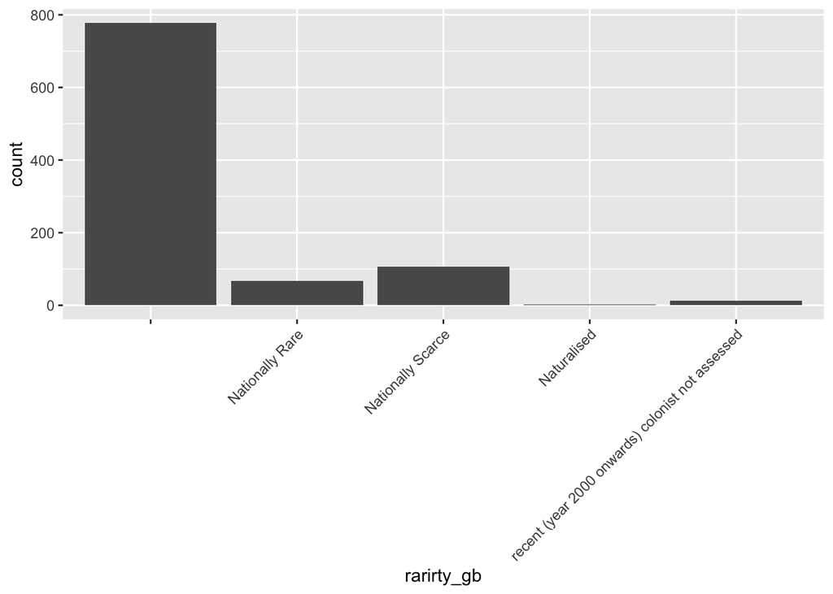

```r
my_ggplot = data %>%
  ggplot(aes(
    x = rarirty_gb)) +
  geom_bar() +
  theme(axis.text.x = element_text(angle = 45, hjust = 1))

plot(my_ggplot)
```

```r
ggplot_data <- ggplot_build(my_ggplot)$data

write.table(ggplot_data, file = "my_ggplot_data.txt", sep = ",")
```